# Stat 365: Statistical Communication

Spring 2024

## Instructor

**Dr. Emily Robinson** *(she/her)*

- Email: erobin17@calpoly.edu
- Office: Building 25 Office 103 (by Statistics Department Office)

## Course information

**Class Meeting Times:** Mondays/Wednesdays

**Class Location:** 010 - 0227

**Office Hours:** in-person (25-103)

- Wednesdays at 1:10pm - 2:30pm
- Thursdays at 9:10 - 10:30am

# Course description

This two-unit course is designed to help students develop strong written communication skills in statistics and data analysis. Through guided practice and feedback, students will learn to effectively communicate statistical ideas and results to different audiences using appropriate graphs and tables. The course will cover strategies for discerning relevant and necessary information and for selecting and describing appropriate methods to analyze data, building on students’ previous statistics coursework.

**Prerequisites:** Completion of GE Area A2, completion of GE Area A3, and a second course in Statistical Methods (STAT 252, STAT 302, or STAT 313).

**Requirements:** This course is required for Statistics majors but does not count toward the Statistics minor or any other degree program. Please speak to your academic adviser if you need permission for credit.

## Course goals

By the end of this course, you will:

- Enhance your written communication skills in statistics and data analysis, specifically through the use of appropriate graphs and tables to convey statistical ideas and results.
- Synthesize output from statistical software to address research questions and analyze data with lexical precision and accuracy.
- Evaluate the statistical background of your intended audience, and adapt the style and content of your written reports to suit their needs and context.
- Demonstrate your understanding of statistical concepts such as parameters versus statistics, variability, p-values, margin-of-error, interaction, and scope of conclusions.
- Develop proficiency in writing and producing technical reports with adequate documentation to ensure reproducibility.
- Learn how to use spreadsheets and R for data visualization and communication.
- Gain experience in integrating statistical analysis, data visualization, and technical writing in a reproducible manner.

# Textbooks

I have reserved eBooks for most of the textbooks and readings through the Cal Poly Library [course reserves](https://reserves.calstate.edu/slo/course/7248728950002920).

The main textbooks used in this course are:

- Communicating with Data: The Art of Writing for Data Science (Deborah Nolan and Sara Stoudt)
- Storytelling with Data (Cole Knaflic)

In addition to the textbooks, there will be a number of readings provided from other texts, including:

- Numbers in the Newsroom (Sarah Cohen)
- The Functional Art (Alberto Cairo)
- Visualize This (Nathan Yau)
- How to Lie with Statistics (Darrell Huff)
- Show Me the Numbers (Stephen Few)
- The Visual Display of Quantitative Information (Edward Tufte)
- Better Data Visualizations (Jonathan Schwabish)

and more.

# Grading

In this class we will be using a contract grading system. This is designed to give flexibility and freedom to explore while ensuring a level of accountability. Learning to write takes practice. I do not want worries about grades to distract us from being creative, taking risks, and ultimately finding our voices.

You are guaranteed a grade of a B for this class if you meet the following conditions:

- Submit assignments (readings, class activities, peer reviews, and final group report check-points) on time and meet the “satisfactory” criteria with a maximum of 3 missed assignments.
- Complete all mini-projects on time and meet the “satisfactory” conditions on the rubrics.
- Submit the final group report on time and meet the “satisfactory” conditions on the rubric.

Your grade will decrease by a third of a step (for example a B to a B-) for each B condition that you do not meet. Missing assignments will be scaled, so that if for example you miss six assignments, turn in two mini-projects late, or turn in your final group report late your grade will decrease by two thirds of a step (for example a B to a C+).

A missing final technical report submission will result in a maximum grade of a D+ at the instructor’s discretion.

You can increase your letter grade by *up to* a third of a step (for example a B to B+) for meeting each of the following conditions to satisfactory as defined on the rubrics (further instructions will be provided):

- Complete a weekly submission to the [NYT: What’s going on in this graph](https://www.nytimes.com/column/whats-going-on-in-this-graph), missing no more than one week throughout the quarter.
- Start a [Dear Data](https://earobinson95.github.io/stat365-calpoly/2024/98-grade-boosters/dear-data.html) “pen pal” with a peer, including at least 1 thoughtful entry (I encourage you to do more!)
- Listen to the [99% Invisible podcast on Florence Nightingale: Data Viz Pioneer](https://99percentinvisible.org/episode/florence-nightingale-data-viz-pioneer/). Find the data set to recreate the rose diagram, compare with a stacked bar plot, discuss the story, and argue why Florence needed the rose diagram.
- [Copy the Masters](https://earobinson95.github.io/stat365-calpoly/2024/98-grade-boosters/copy-the-masters.html) by recreating a graphic from FiveThirtyEight using your favorite software.
- [Make your own website](https://earobinson95.github.io/stat365-calpoly/98-grade-boosters/make-your-own-website.html) using Quarto and GitHub pages to showcase your statistical projects.
- In addition to the mini-project for building your Resume, find an internship/program and write a Tailored Cover Letter.
- Complete a final group report project that goes above and beyond the requirements. Your job is to convince me in an additional half page document why you think your contribution goes the extra mile.
- I encourage you to suggest your own “boosting” condition via the suggestion “box” form on Canvas.

For example, to earn an A in this class you must meet the conditions for a B and complete three of the “boosting” conditions above to “satisfactory” quality.

Any deviation from the grading policies outlined above will only be to your benefit.

## Grade Breakdown

1. **Readings and participation:**

You will be expected to complete assigned readings before coming to class and participate in class discussions and activities. Your peer review participation and engagement in class will be evaluated throughout the quarter.

2. **In-class activities:**

Most classes will involve activities to help you develop your technical writing and communication skills. These will include assignments such as summarizing statistical findings, redesigning graphs and tables, and story-boarding your data analysis. These assignments will be designed to help you practice communicating complex statistical concepts and analyses clearly and effectively.

3. **Mini-projects:**

There will be three mini-projects throughout the quarter, each designed to help you develop and apply your statistical communication skills. Additionally, the first two mini-projects will build into your final group report. Mini-projects are to be completed *individually.* The mini-projects will include:

- [*One Number Story:*](https://earobinson95.github.io/stat365-calpoly/2024/97-mini-projects/01-one-number-story/one-number-story.html) In this assignment, you will choose a single number that summarizes a key finding from the data set your group selected for your final report and craft a compelling story around it, using appropriate statistical evidence to support your claims.
- [*Data Narrative Visualization:*](https://earobinson95.github.io/stat365-calpoly/2024/97-mini-projects/02-stand-alone-graphic/stand-alone-graphic.html) For this assignment, you will create a visually compelling and informative visualization that tells a story based on the data set your group selected for the final report. Your task is to design a graphic that stands on its own, effectively communicating key insights and trends from the data.
- [*Build your resume:*](https://earobinson95.github.io/stat365-calpoly/2024/97-mini-projects/03-build-your-resume/build-your-resume.html) In this assignment, you will create a resume using Overleaf to highlight your education, statistical communication and technical skills, statistics and data science projects, and other relevant experiences.

Detailed rubrics will be provided for each mini-project to help guide your work and ensure that you meet the required standards.

4. **Group final report:**

The group final report is the culminating assignment of the course, where you will have the opportunity to apply all the skills and knowledge you have acquired throughout the quarter. This will be completed in *groups of three to four individuals*. You will be required to choose a data set from [TidyTuesday](https://github.com/rfordatascience/tidytuesday) and investigate a research question related to the data. You will analyze the data using appropriate statistical methods and produce a technical report that effectively communicates your findings in written, graphical, and table format. You will be provided with guidelines and resources to support your work, and you will receive feedback and guidance throughout the project. The group report will be evaluated based on its clarity, thoroughness, and adherence to standard statistical practices.

A portion of the rubric will be dedicated to effective and equitable collaboration efforts.

## Late work

I understand that unexpected events may arise during the quarter that may prevent you from submitting your assignments on time. To accommodate for this, you will be given three 24-hour late submission “Grace Days” to use on In-class Activities and Mini-projects throughout the quarter. To use a “Grace Day”, you must (1) send me an email and (2) comment on the Canvas submission.

These “Grace Days” **cannot** be used on your final group report submission.

Your remaining “Grace Days” will be tracked in a Canvas assignment as three points, with each “Grace Day” worth one point.

## Live Revisions

In-class Activities and Mini-projects are subject to revisions if “satisfactory” is not met. If you do not receive, satisfactory, you are expected to revise your submission based on my feedback. For In-class activities, please stop by my office hours to talk me through your changes and why it now meets satisfactory requirements. For mini-projects, please schedule a 10-minute meeting with me via a provided Calendly link on Canvas (this will be set up for specific weeks after mini-project due dates).

Booster Conditions will be given “Best By” dates for deadlines. If you turn the assignment in by the “Best By” date, you will receive feedback and an opportunity to revise before the end of the quarter. Booster conditions may still be accepted past the “Best By” date, but will not be graded until finals week leaving no opportunity for revisions if the instructor determines “satisfactory” quality is not met.

*Disclaimer: I’ve never done Live Revisions, but wanted to try it!“*

# Class Schedule

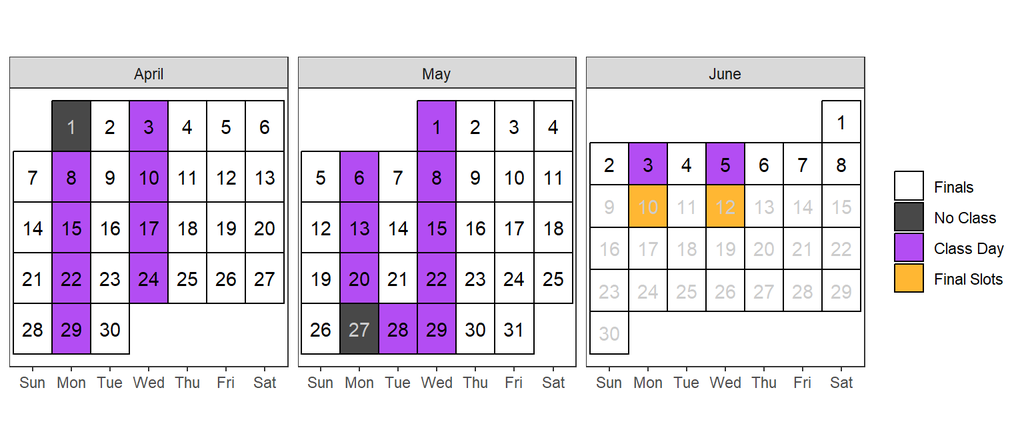

Note: Tuesday, May 28th follows a Monday Schedule.

This schedule is **very** tentative and subject to change.

[output not shown]

# Course Expectations

You will get out of this course what you put in. The following excerpt was taken from Rob Jenkins’ article “Defining the Relationship” which was published in The Chronicle of Higher Education (August 8, 2016). This accurately summarizes what I expect of you in my classroom (and also what you should expect of me).

*“I’d like to be your partner. More than anything, I’d like for us to form a mutually beneficial alliance in this endeavor we call education.*

*I pledge to do my part. I will:*

- *Stay abreast of the latest ideas in my field.*
- *Teach you what I believe you need to know; with all the enthusiasm I possess.*
- *Invite your comments and questions and respond constructively.*
- *Make myself available to you outside of class (within reason).*
- *Evaluate your work carefully and return it promptly with feedback.*
- *Be as fair, respectful, and understanding as I can humanly be.*
- *If you need help beyond the scope of this course, I will do my best to provide it or see that you get it.*

*In return, I expect you to:*

- *Show up for class each day or let me know (preferably in advance) if you have some good reason to be absent.*
- *Do your reading and other assignments outside of class and be prepared for each class meeting.*
- *Focus during class on the work we’re doing and not on extraneous matters (like whoever or whatever is on your phone at the moment).*
- *Participate in class discussions.*
- *Be respectful of your fellow students and their points of view.*
- *In short, I expect you to devote as much effort to learning as I devote to teaching.*

*What you get out of this relationship is that you’ll be better equipped to succeed in this and other college courses, work-related assignments, and life in general. What I get is a great deal of professional and personal satisfaction. Because I do really like you [all] and want the best for you.”*

# Learning Environment and Support

I am committed to creating a safe and inclusive learning environment where all students feel respected and supported. If there are any ways I can improve the classroom environment to make it more welcoming for you, please don’t hesitate to let me know.

If you have a disability and require accommodations to fully participate in the course, please contact me as soon as possible to discuss how I can best support you. I also encourage you to register with Cal Poly’s Disability Resource Center (Building 124, Room 119 or at 805-756-1395) to explore additional accommodations that may be available to you.

If you are experiencing food insecurity, housing instability, or other challenges that may impact your ability to succeed in this course, please refer to the resources listed on Canvas under “Student Support Services at Cal Poly.” These resources provide a range of essential support services, including emergency financial assistance, counseling, and academic support.

I am committed to working with you to ensure that you have the resources and support you need to succeed in this course. Let’s work together to create a positive and inclusive learning environment for all students.

# Academic Integrity

Academic integrity is a fundamental value of this course and of the university. Simply put, I will not tolerate cheating, plagiarism, or any other form of academic dishonesty.

Any incident of academic misconduct, including dishonesty, copying, or plagiarism, will be reported to the Office of Student Rights and Responsibilities.

Cheating or plagiarism will result in an incomplete grade for the assignment and an overall grade deduction of one-third (e.g., B to a B-). In cases of flagrant cheating, a grade of F for the course may be assigned.

It is important to note that paraphrasing or quoting another’s work without proper citation is a form of academic misconduct. This includes using Chat GPT, which should only be used to generate ideas and not as a substitute for your own work.

To ensure academic integrity, please be sure to cite all sources appropriately and only use Chat GPT in an ethical manner. For more information on academic misconduct and what constitutes cheating and plagiarism, please see academicprograms.calpoly.edu/content/academicpolicies/Cheating.

# Acknowledgments

I would like to acknowledge the contributions of various individuals whose work has been incorporated into this course. Special thanks to Beth Chance, Allan Rossman, Amelia McNamara, and Sara Stoudt for their valuable materials and inspiration.